# Лабораторная работа №6

Bibliography Management in LaTeX

Усман Траоре

Российский университет дружбы народов, Москва, Россия

14 ноября 2025

# Цель работы

## Основная цель

Освоение использования **natbib**, **BibTeX**, **biblatex** и **Biber**, изучение порядка компиляции и анализ различий между системами управления библиографией.

# Работа с natbib и BibTeX

## Первый проход pdflatex

- компилятор сообщает об отсутствующих ссылках,
- предупреждения об `undefined citations`,
- PDF создаётся, но ссылки не определены.

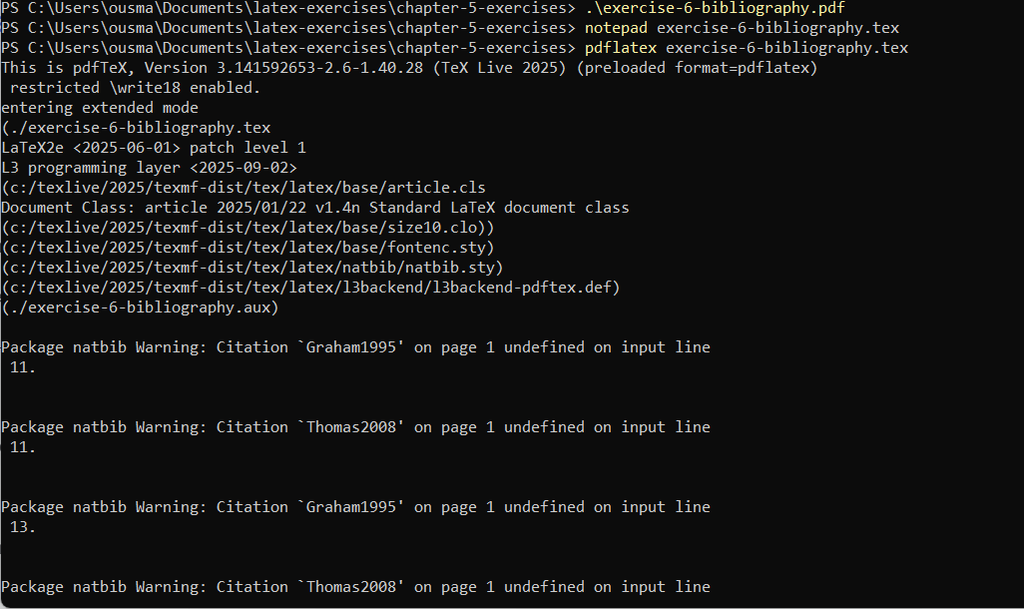

Предупреждения natbib

## Запуск BibTeX

- обработка файла `.aux`,
- подключение базы `references.bib`,
- создание `.bbl`.

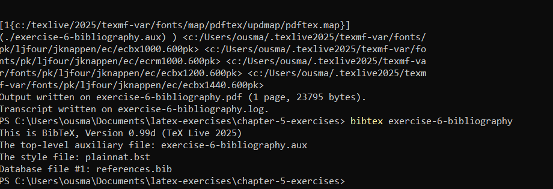

Подключение BibTeX

## Последующие проходы pdflatex

- первый — всё ещё предупреждения,
- второй — ссылки разрешены,
- третий — чистая компиляция без ошибок.

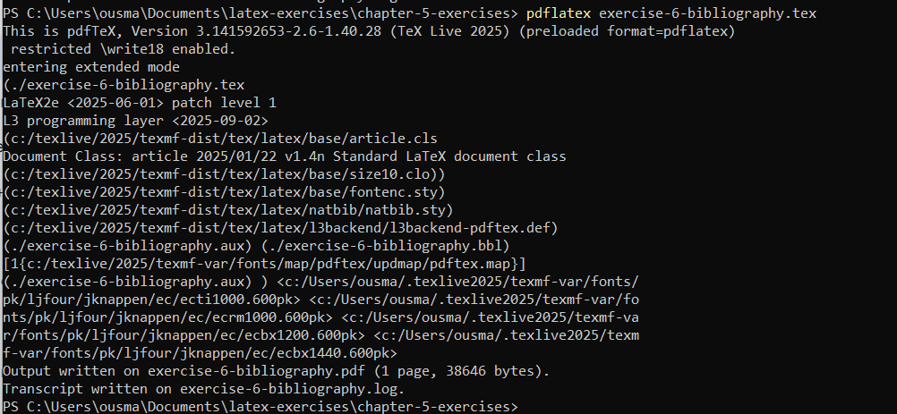

Финальная компиляция natbib

## Результат

- корректное отображение цитат,
- список литературы сформирован автоматически.

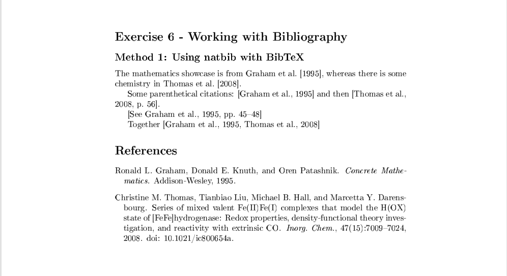

Готовый PDF natbib

# Установка и использование biblatex + Biber

## Установка пакетов

Команды:

- `tlmgr update --self`
- `tlmgr install biblatex biber`

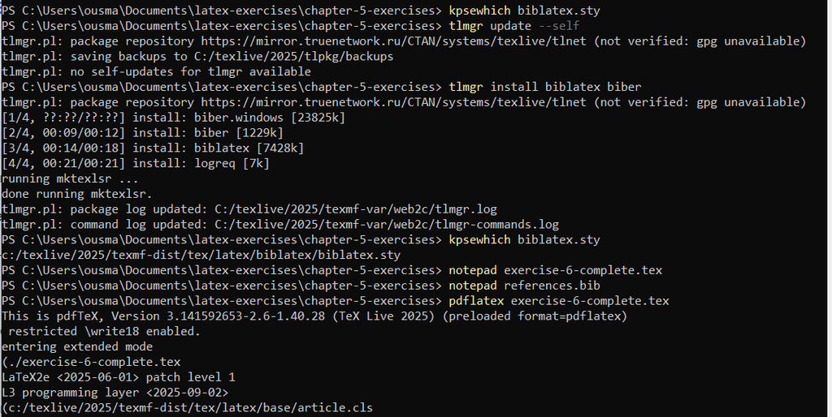

Установка biber

## Последовательность компиляции

1. `pdflatex`
2. `biber`
3. `pdflatex`

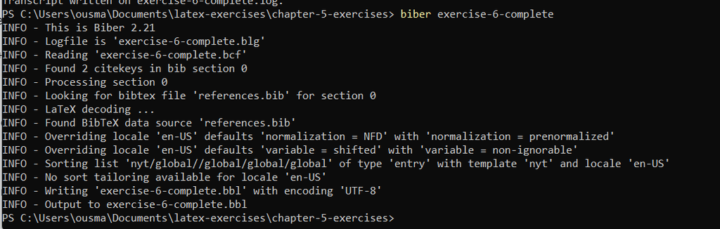

Запуск biber

## Результат

- корректная обработка библиографии,
- красивое форматирование,
- автоматическое создание списка литературы.

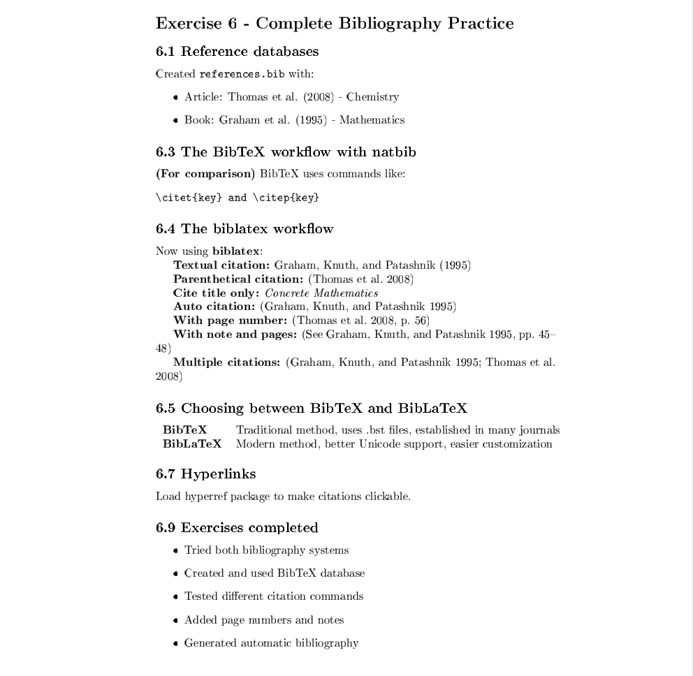

Документ с biblatex

# Дополнительная компиляция biblatex

## Первый проход

LaTeX корректно загрузил `biblatex`, сформировал структуру документа.

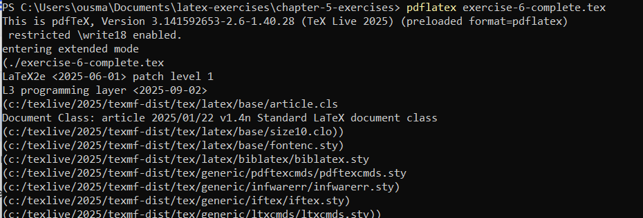

Первый проход biblatex

## Финальный PDF

- сравнение методов,
- разные стили цитирования,
- автогенерация списка литературы.

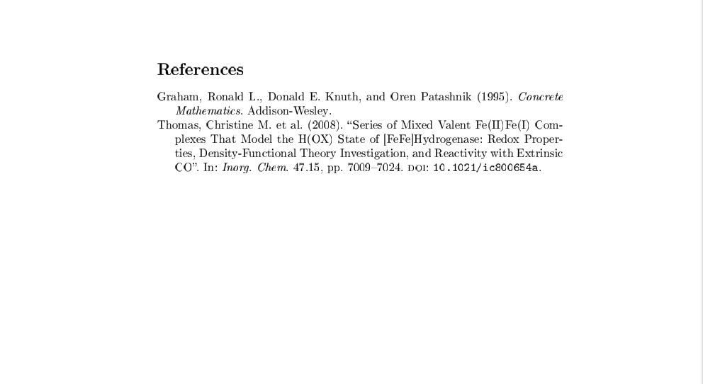

Готовый PDF biblatex

# Оба метода в одном документе

## Работа с файлом exercise-6-both-methods.tex

- запуск BibTeX для natbib-блока,
- компиляция pdflatex два раза,
- обработка смешанного документа.

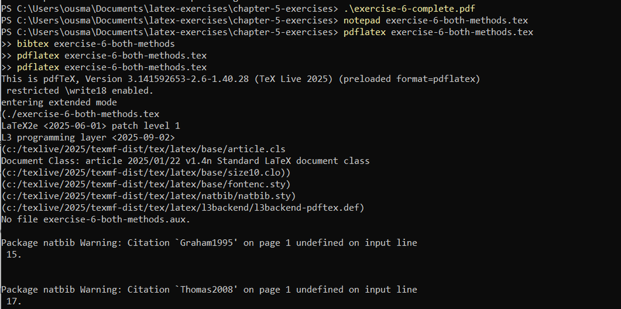

Компиляция смешанного документа

## Итоги

Корректное отображение:

- текстовых цитат,
- скобочных,
- множественных.

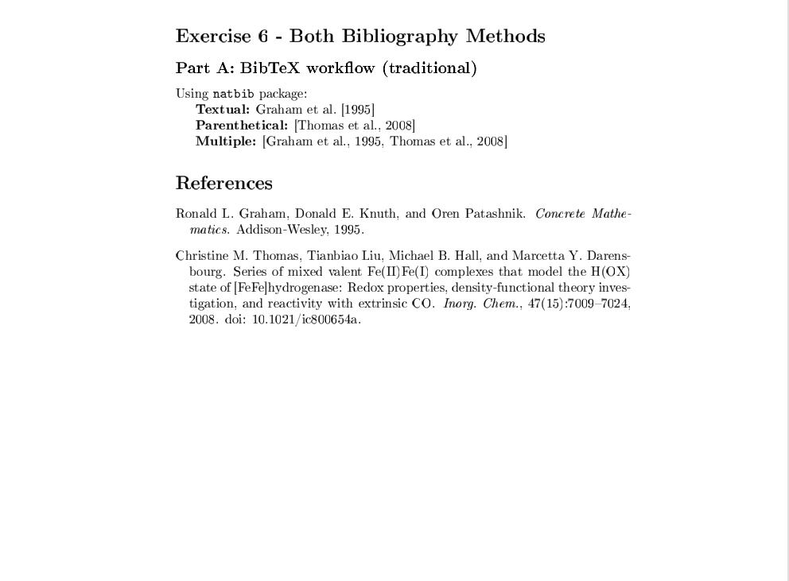

Итоговый PDF для обоих методов

# Итоги работы

## Вывод

В ходе работы были освоены:

- применение двух систем библиографии: **BibTeX/natbib** и **BibLaTeX/Biber**;
- порядок компиляции для каждой системы;
- создание и подключение собственных записей в `.bib`;
- анализ поведения при отсутствии ключей;
- получение корректного списка литературы через обе системы.

Обе методики успешно работают и позволяют гибко оформлять научные документы.